# Chapter 4 - Classification

## 4.6.1 - The Stock Market Data

Daily percentage returns for the S&P 500 stock index between 2001 and 2005.

```r
library(ISLR)
names(Smarket)
```

```
## [1] "Year"      "Lag1"      "Lag2"      "Lag3"      "Lag4"      "Lag5"
## [7] "Volume"    "Today"     "Direction"
```

**Format**

A data frame with 1250 observations on the following 9 variables.

- `Year` - The year that the observation was recorded
- `Lag1` - Percentage return for previous day
- `Lag2`, `Lag3`, `Lag4`, `Lag5`
- `Volume` - Volume of shares traded (number of daily shares traded in billions)
- `Today` - Percentage return for today
- `Direction` - A factor with levels Down and Up indicating whether the market had a positive or negative return on a given day

```r
dim(Smarket)
```

```
## [1] 1250    9
```

```r
summary(Smarket)
```

```
##       Year           Lag1                Lag2
##  Min.   :2001   Min.   :-4.922000   Min.   :-4.922000
##  1st Qu.:2002   1st Qu.:-0.639500   1st Qu.:-0.639500
##  Median :2003   Median : 0.039000   Median : 0.039000
##  Mean   :2003   Mean   : 0.003834   Mean   : 0.003919
##  3rd Qu.:2004   3rd Qu.: 0.596750   3rd Qu.: 0.596750
##  Max.   :2005   Max.   : 5.733000   Max.   : 5.733000
##       Lag3                Lag4                Lag5
##  Min.   :-4.922000   Min.   :-4.922000   Min.   :-4.92200
##  1st Qu.:-0.640000   1st Qu.:-0.640000   1st Qu.:-0.64000
##  Median : 0.038500   Median : 0.038500   Median : 0.03850
##  Mean   : 0.001716   Mean   : 0.001636   Mean   : 0.00561
##  3rd Qu.: 0.596750   3rd Qu.: 0.596750   3rd Qu.: 0.59700
##  Max.   : 5.733000   Max.   : 5.733000   Max.   : 5.73300
##      Volume           Today           Direction
##  Min.   :0.3561   Min.   :-4.922000   Down:602
##  1st Qu.:1.2574   1st Qu.:-0.639500   Up  :648
##  Median :1.4229   Median : 0.038500
##  Mean   :1.4783   Mean   : 0.003138
##  3rd Qu.:1.6417   3rd Qu.: 0.596750
##  Max.   :3.1525   Max.   : 5.733000
```

Correlation matrix of all quantitivate fields (i.e. except for `Direction`)

```r
cor(Smarket[,-9])
```

```
##              Year         Lag1         Lag2         Lag3         Lag4
## Year   1.00000000  0.029699649  0.030596422  0.033194581  0.035688718
## Lag1   0.02969965  1.000000000 -0.026294328 -0.010803402 -0.002985911
## Lag2   0.03059642 -0.026294328  1.000000000 -0.025896670 -0.010853533
## Lag3   0.03319458 -0.010803402 -0.025896670  1.000000000 -0.024051036
## Lag4   0.03568872 -0.002985911 -0.010853533 -0.024051036  1.000000000
## Lag5   0.02978799 -0.005674606 -0.003557949 -0.018808338 -0.027083641
## Volume 0.53900647  0.040909908 -0.043383215 -0.041823686 -0.048414246
## Today  0.03009523 -0.026155045 -0.010250033 -0.002447647 -0.006899527
##                Lag5      Volume        Today
## Year    0.029787995  0.53900647  0.030095229
## Lag1   -0.005674606  0.04090991 -0.026155045
## Lag2   -0.003557949 -0.04338321 -0.010250033
## Lag3   -0.018808338 -0.04182369 -0.002447647
## Lag4   -0.027083641 -0.04841425 -0.006899527
## Lag5    1.000000000 -0.02200231 -0.034860083
## Volume -0.022002315  1.00000000  0.014591823
## Today  -0.034860083  0.01459182  1.000000000
```

Little correlations between the `Lag` variables.

Large correlation between `Year` and `Volume`.

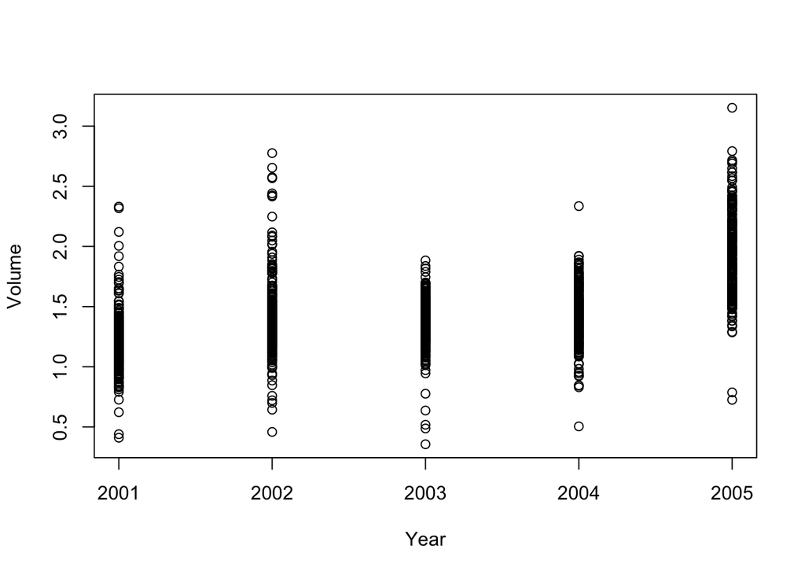

```r
attach(Smarket)
plot(x = Year, y = Volume)
```

`Volume` is increasing over time.

## 4.6.2 - Logistic Regression

Goal: predict `Direction` using `Lag` variables and `Volume`.

Logistic regression: use `glm()` with `family = binomial`.

```r
glm.fits = glm(Direction ~ Lag1 + Lag2 + Lag3 + Lag4 + Lag5 + Volume,
               data = Smarket,
               family = binomial)

summary(glm.fits)
```

```
##
## Call:
## glm(formula = Direction ~ Lag1 + Lag2 + Lag3 + Lag4 + Lag5 +
##     Volume, family = binomial, data = Smarket)
##
## Deviance Residuals:
##    Min      1Q  Median      3Q     Max
## -1.446  -1.203   1.065   1.145   1.326
##
## Coefficients:
##              Estimate Std. Error z value Pr(>|z|)
## (Intercept) -0.126000   0.240736  -0.523    0.601
## Lag1        -0.073074   0.050167  -1.457    0.145
## Lag2        -0.042301   0.050086  -0.845    0.398
## Lag3         0.011085   0.049939   0.222    0.824
## Lag4         0.009359   0.049974   0.187    0.851
## Lag5         0.010313   0.049511   0.208    0.835
## Volume       0.135441   0.158360   0.855    0.392
##
## (Dispersion parameter for binomial family taken to be 1)
##
##     Null deviance: 1731.2  on 1249  degrees of freedom
## Residual deviance: 1727.6  on 1243  degrees of freedom
## AIC: 1741.6
##
## Number of Fisher Scoring iterations: 3
```

Smallest p-value is with `Lag1` at 0.145, which is still quite large.

Predict the training set and return the logit value.

```r
predict(glm.fits)[1:10]
```

```
##           1           2           3           4           5           6
##  0.02833843 -0.07416246 -0.07548047  0.06090825  0.04313134  0.02782764
##           7           8           9          10
## -0.02939862  0.03692083  0.07048327 -0.04465630
```

Now, return the response `Pr(Y = 1 | X)`.

```r
glm.probs = predict(glm.fits, type = "response")

glm.probs[1:10]
```

```
##         1         2         3         4         5         6         7
## 0.5070841 0.4814679 0.4811388 0.5152224 0.5107812 0.5069565 0.4926509
##         8         9        10
## 0.5092292 0.5176135 0.4888378
```

```r
contrasts(Direction)
```

```
##      Up
## Down  0
## Up    1
```

We need to convert the predcited probabilities into class labels.

```r
glm.pred = rep("Down", 1250) # Create a vector of class predictions, initialize with "Down"

glm.pred[glm.probs > 0.5] = "Up" # Update using the predicted probabilities with 0.5 as the threshold
```

Confusion matrix.

```r
table(glm.pred, Direction)
```

```
##         Direction
## glm.pred Down  Up
##     Down  145 141
##     Up    457 507
```

Type I Error = FP Rate = FP / N.

```r
457 / (145 + 457)
```

```
## [1] 0.7591362
```

Type II Error = FN Rate = FN / P.

```r
141 / (141 + 507)
```

```
## [1] 0.2175926
```

`mean()` can be used to compute the fraction of days for which the prediction was correct.

```r
mean(glm.pred == Direction)
```

```
## [1] 0.5216
```

```r
(145 + 507) / 1250
```

```
## [1] 0.5216
```

This means that the `training` error rate is `1 - 52.16% = 47.84%`.

Now, let’s use 2005 as the `holdout` set instead.

```r
train = (Year < 2005) # A vector of Booleans

Smarket.2005 = Smarket[!train, ] # Submatrix of Smarket

dim(Smarket.2005)
```

```
## [1] 252   9
```

```r
Direction.2005 = Direction[!train]
```

Now fit pre-2005 data and predict the 2005 data.

```r
glm.fits = glm(Direction ~ Lag1 + Lag2 + Lag3 + Lag4 + Lag5 + Volume,
               data = Smarket,
               family = binomial,
               subset = train) # Using the `subset` parameter

summary(glm.fits)
```

```
##
## Call:
## glm(formula = Direction ~ Lag1 + Lag2 + Lag3 + Lag4 + Lag5 +
##     Volume, family = binomial, data = Smarket, subset = train)
##
## Deviance Residuals:
##    Min      1Q  Median      3Q     Max
## -1.302  -1.190   1.079   1.160   1.350
##
## Coefficients:
##              Estimate Std. Error z value Pr(>|z|)
## (Intercept)  0.191213   0.333690   0.573    0.567
## Lag1        -0.054178   0.051785  -1.046    0.295
## Lag2        -0.045805   0.051797  -0.884    0.377
## Lag3         0.007200   0.051644   0.139    0.889
## Lag4         0.006441   0.051706   0.125    0.901
## Lag5        -0.004223   0.051138  -0.083    0.934
## Volume      -0.116257   0.239618  -0.485    0.628
##
## (Dispersion parameter for binomial family taken to be 1)
##
##     Null deviance: 1383.3  on 997  degrees of freedom
## Residual deviance: 1381.1  on 991  degrees of freedom
## AIC: 1395.1
##
## Number of Fisher Scoring iterations: 3
```

```r
glm.probs = predict(glm.fits,
                    Smarket.2005,
                    type = "response")
```

Confusion matrix and error rate.

```r
glm.pred = rep("Down", 252) # Test set

glm.pred[glm.probs > 0.5] = "Up"

table(glm.pred, Direction.2005)
```

```
##         Direction.2005
## glm.pred Down Up
##     Down   77 97
##     Up     34 44
```

```r
mean(glm.pred == Direction.2005)
```

```
## [1] 0.4801587
```

```r
mean(glm.pred != Direction.2005)
```

```
## [1] 0.5198413
```

A test error rate of 52% is worse than random guessing!

Now, try to predict use only `Lag1` and `Lag2`.

```r
glm.fits = glm(Direction ~ Lag1 + Lag2,
               data = Smarket,
               family = binomial,
               subset = train)

summary(glm.fits)
```

```
##
## Call:
## glm(formula = Direction ~ Lag1 + Lag2, family = binomial, data = Smarket,
##     subset = train)
##
## Deviance Residuals:
##    Min      1Q  Median      3Q     Max
## -1.345  -1.188   1.074   1.164   1.326
##
## Coefficients:
##             Estimate Std. Error z value Pr(>|z|)
## (Intercept)  0.03222    0.06338   0.508    0.611
## Lag1        -0.05562    0.05171  -1.076    0.282
## Lag2        -0.04449    0.05166  -0.861    0.389
##
## (Dispersion parameter for binomial family taken to be 1)
##
##     Null deviance: 1383.3  on 997  degrees of freedom
## Residual deviance: 1381.4  on 995  degrees of freedom
## AIC: 1387.4
##
## Number of Fisher Scoring iterations: 3
```

```r
glm.probs = predict(glm.fits,
                    Smarket.2005,
                    type = "response")

glm.pred = rep("Down", 252)

glm.pred[glm.probs > 0.5] = "Up"

table(glm.pred, Direction.2005)
```

```
##         Direction.2005
## glm.pred Down  Up
##     Down   35  35
##     Up     76 106
```

```r
mean(glm.pred == Direction.2005)
```

```
## [1] 0.5595238
```

Slightly better results.

To predict the probabilities associated with particular values of `Lag1` and `Lag2`.

```r
predict(glm.fits,
        newdata = data.frame(Lag1 = c(1.5),
                             Lag2 = c(-0.8)),
        type = "response")
```

```
##         1
## 0.4960939
```

## 4.6.3 - Linear Discriminant Analysis

The `lda()` function is part of the `MASS` library. Syntax is identical to that of `glm()` except for the absence of the `family` option.

Let’s only use one predictor - `Lag1`

```r
library(MASS)

lda.fit = lda(Direction ~ Lag1,
              data = Smarket,
              subset = train)

lda.fit # No more `summary()`
```

```
## Call:
## lda(Direction ~ Lag1, data = Smarket, subset = train)
##
## Prior probabilities of groups:
##     Down       Up
## 0.491984 0.508016
##
## Group means:
##             Lag1
## Down  0.04279022
## Up   -0.03954635
##
## Coefficients of linear discriminants:
##            LD1
## Lag1 0.8132776
```

Prior probabilities: $\hat{\pi}_1$ = 0.491, $\hat{\pi}_2$ = 0.508. This means that, 49.2% of training observations corrspond to days during which the market went down.

```r
sum(Direction[train] == "Down") / length(Direction[train])
```

```
## [1] 0.491984
```

The `group means` will be used as estimtes for $\mu_1$ and $\mu_2$. They are the average of all the training observations from the *k*th class. These values suggest that, when the previous day’s return is positive, market is likely to go down, and vice verse.

```r
mean(Smarket[(train) & (Direction == "Down"), ]$Lag1)
```

```
## [1] 0.04279022
```

```r
mean(Smarket[(train) & (Direction == "Up"), ]$Lag1)
```

```
## [1] -0.03954635
```

The `coefficients of linear discriminants` provides the linear combination of `Lag1` that is used to form the LDA decision rule. If $0.813 \times Lag1$ is large, then the LDA classifier will predict a market decrease.

`plot()` produces plots of the `linear discrimants`, obtained by computing $0.813 \times Lag1$ for each training observation.

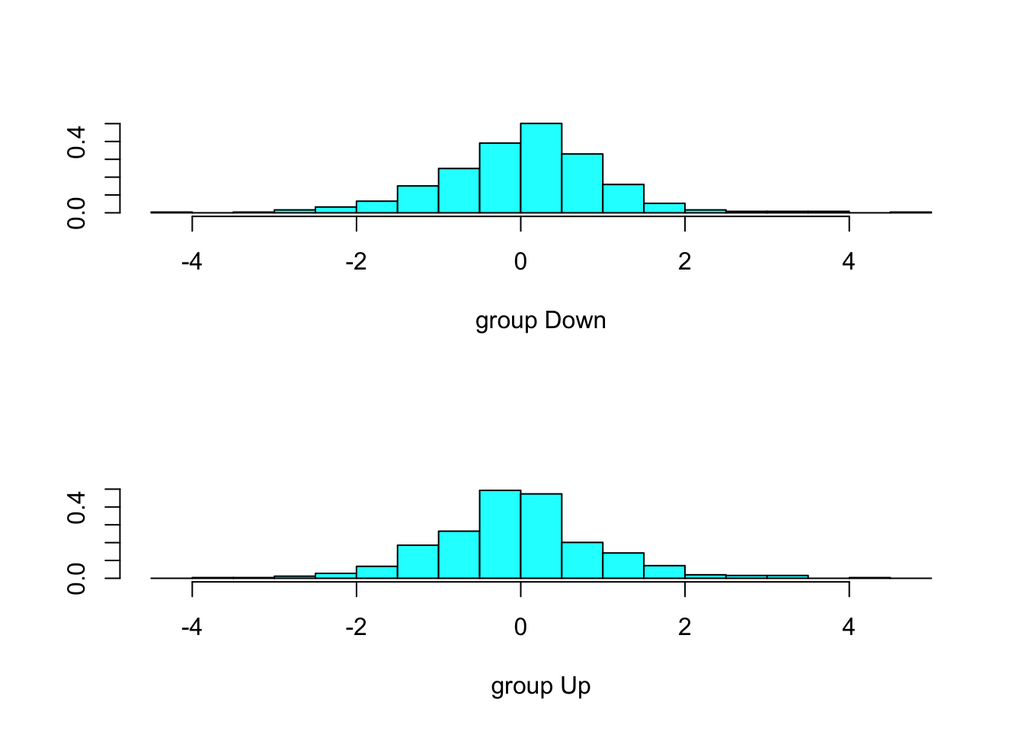

```r
plot(lda.fit)
```

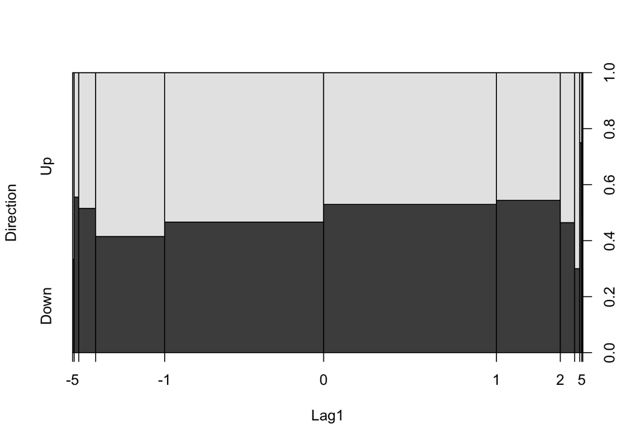

```r
plot(Direction ~ Lag1, data = Smarket[train,])
```

`predict()` returns three elements:

- `class` - LDA’s prediction
- `posterior` - a matrix whose *k*th column contains the posterior probability that the corresponding observation belongs to the *k*th class
- `x` - linear discriminants

```r
lda.pred = predict(lda.fit, Smarket.2005)

names(lda.pred)
```

```
## [1] "class"     "posterior" "x"
```

```r
lda.pred$class[1:15]
```

```
##  [1] Up   Up   Up   Up   Up   Up   Up   Up   Up   Up   Down Down Up   Up
## [15] Up
## Levels: Down Up
```

```r
lda.pred$posterior[1:15]
```

```
##  [1] 0.4901381 0.4809153 0.4760910 0.4870220 0.4967400 0.4900156 0.4966175
##  [8] 0.4836620 0.4973799 0.4802220 0.5001301 0.5051265 0.4790530 0.4813775
## [15] 0.4832404
```

Note that the posterior probability output by the model corresponds to the probability that the market will **decrease**, opposite of logistic regression.

```r
lda.pred$x[1:10]
```

```
##  [1] -0.1097615 -0.6611637 -0.9498773 -0.2960021  0.2846781 -0.1170810
##  [7]  0.2773586 -0.4968816  0.3229022 -0.7026409
```

Let’s use the first observation as an example, where $x$ is -0.134.

```r
Smarket[!train,]$Lag1[1]
```

```
## [1] -0.134
```

```r
predict(lda.fit,
        newdata = data.frame(Lag1 = c(-0.134)))
```

```
## $class
## [1] Up
## Levels: Down Up
##
## $posterior
##        Down        Up
## 1 0.4901381 0.5098619
##
## $x
##          LD1
## 1 -0.1097615
```

Since

$$\hat{\delta}_k(x) = x \cdot \frac{\hat{\mu}_k}{\hat{\sigma}^2} - \frac{\hat{\mu}_k^2}{2\hat{\sigma}^2} + \log{(\hat{\pi}_k)}$$

Where

$$\hat{\mu}_k = \frac {1} {n_k} \sum_{i:y_i = k}^{}x_i$$

$$\hat{\sigma}^2 = \frac {1} {n - K} \sum_{k = 1}^{K} \sum_{i:y_i = k}^{} (x_i - \hat{\mu}_k)^2$$

$\hat{\mu}_1$ is the group means of the `Down` class, which equals to 0.04279022.

$\hat{\sigma}^2$ is a weighted average of the sample varaince for each of the K classes

```r
var(Smarket[(train) & (Direction == "Down"), ]$Lag1)
```

```
## [1] 1.506623
```

```r
var(Smarket[(train) & (Direction == "Up"), ]$Lag1)
```

```
## [1] 1.517006
```

```r
length(Smarket[(train) & (Direction == "Down"),1])
```

```
## [1] 491
```

```r
length(Smarket[(train) & (Direction == "Up"),1])
```

```
## [1] 507
```

$$\hat{\sigma}^2 = \frac {1.506623 \times 491 + 1.517006 \times 507} {491 + 507 - 2}
\\
\hat{\sigma}^2 = 1.514934$$

```r
(1.506623 * 491 + 1.517006 * 507) / (491 + 507 - 2)
```

```
## [1] 1.514934
```

Finally,

$$\hat{\delta}_1(x) = -0.134 \cdot \frac{0.04279022}{1.514934} - \frac{0.04279022^2}{2 \times 1.514934} + \log{(0.491984)}
\\
\hat{\delta}_1(x) = -0.7136983$$

```r
-0.134 * (0.04279022 / 1.514934) - (0.04279022^2 / (2 * 1.514934)) + log(0.491984)
```

```
## [1] -0.7136983
```

```r
exp(-0.7136983)
```

```
## [1] 0.4898293
```

$$\hat{\delta}_2(x) = -0.134 \cdot \frac{-0.03954635}{1.514934} - \frac{-0.03954635^2}{2 \times 1.514934} + \log{(0.508016)}
\\
\hat{\delta}_2(x) = -0.6742605$$

```r
-0.134 * (-0.03954635 / 1.514934) - ((-0.03954635)^2 / (2 * 1.514934)) + log(0.508016)
```

```
## [1] -0.6742605
```

```r
exp(-0.6742605)
```

```
## [1] 0.5095331
```

Very close to what the package predicted. Since class 2 is larger, we assign the first observation to class 2 (i.e. `Up`).

```r
lda.class = lda.pred$class

table(lda.class, Direction.2005)
```

```
##          Direction.2005
## lda.class Down  Up
##      Down   20  25
##      Up     91 116
```

```r
mean(lda.class == Direction.2005)
```

```
## [1] 0.5396825
```

Apply a 50% threshold, we can recreate the predictions

```r
sum(lda.pred$posterior[,1] >= 0.5) # Down
```

```
## [1] 45
```

```r
sum(lda.pred$posterior[,1] < 0.5) # Up
```

```
## [1] 207
```

If we want to use another threshold (say 51%), then

```r
sum(lda.pred$posterior[,1] >= 0.51)
```

```
## [1] 5
```

## 4.6.4 - Quadratic Discriminant Analysis

QDA is implemented using the `qda()` function, also part of the `MASS` library.

```r
qda.fit = qda(Direction ~ Lag1 + Lag2,
              data = Smarket,
              subset = train)

qda.fit
```

```
## Call:
## qda(Direction ~ Lag1 + Lag2, data = Smarket, subset = train)
##
## Prior probabilities of groups:
##     Down       Up
## 0.491984 0.508016
##
## Group means:
##             Lag1        Lag2
## Down  0.04279022  0.03389409
## Up   -0.03954635 -0.03132544
```

Notice that QDA does **not* contain `coefficients of linear discriminants`, because it is not linear!

```r
qda.class = predict(qda.fit, Smarket.2005)$class

table(qda.class, Direction.2005)
```

```
##          Direction.2005
## qda.class Down  Up
##      Down   30  20
##      Up     81 121
```

```r
mean(qda.class == Direction.2005)
```

```
## [1] 0.5992063
```

Better model performance than LDA.

## 4.6.5 - K-Nearest Neighbors

`knn()` is part of the `class` library. It forms predictions using a single command with four inputs:

- `train.X` - a matrix cnontaining the predictors associated with the training data
- `test.X` - a matrix containing the predictors associated with the test data
- `train.Direction` - a vector containing the class labels for the traning data
- `K` - the number of nearest neighbors

```r
library(class)
```

The `cbind()` (column bind) function is used to bind `Lag1` and `Lag2` together.

```r
train.X = cbind(Lag1, Lag2)[train,]

test.X = cbind(Lag1, Lag2)[!train,]

train.Direction = Direction[train]

# test.Direction is Direction.2005
```

```r
dim(train.X)
```

```
## [1] 998   2
```

```r
train.X[1:5,]
```

```
##        Lag1   Lag2
## [1,]  0.381 -0.192
## [2,]  0.959  0.381
## [3,]  1.032  0.959
## [4,] -0.623  1.032
## [5,]  0.614 -0.623
```

We also need to set a random seed because if several observations are tied as nearest neighbor, R randomly breaks the tie.

Let’s use `k` = 1 first.

```r
set.seed(647)

knn.pred = knn(train.X,
               test.X,
               train.Direction,
               k = 1)

table(knn.pred, Direction.2005)
```

```
##         Direction.2005
## knn.pred Down Up
##     Down   43 58
##     Up     68 83
```

```r
mean(knn.pred == Direction.2005)
```

```
## [1] 0.5
```

Now use `k` = 3.

```r
knn.pred = knn(train.X,
               test.X,
               train.Direction,
               k = 3)

table(knn.pred, Direction.2005)
```

```
##         Direction.2005
## knn.pred Down Up
##     Down   48 55
##     Up     63 86
```

```r
mean(knn.pred == Direction.2005)
```

```
## [1] 0.531746
```

Slightly better results.